# Getting Started With the COVID-19 Data: Classification

Michael Hahsler

2021-04-13

I use mostly tidyverse and ggplot. The focus of the analysis is Texas and Dallas County, TX.

```r
library("tidyverse")
library("DT")
```

# COVID 19 Cases in Texas Counties

https://console.cloud.google.com/marketplace/details/usafacts-public-data/covid19-us-cases?filter=solution-type:dataset&filter=category:covid19&id=3eaff9c5-fbaf-47bb-a441-89db1e1395ab

using the query

> ```
> SELECT *
> FROM `bigquery-public-data.covid19_usafacts.summary` covid19
> JOIN `bigquery-public-data.census_bureau_acs.county_2017_5yr` acs
> ON covid19.county_fips_code = acs.geo_id
> WHERE date = DATE_SUB(CURRENT_DATE(), INTERVAL 7 day)
> ```

**You will need newer data and probably also trend variables (change during the last week)**

# Read and prepare data

```r
cases <- read_csv("COVID-19_cases_plus_census.csv")
cases
```

```
## # A tibble: 3,142 x 259
##    county_fips_code county_name state state_fips_code date       confirmed_cases
##    <chr>            <chr>       <chr> <chr>           <date>               <dbl>
##  1 50009            Essex Coun… VT    50              2021-01-19             111
##  2 50007            Chittenden… VT    50              2021-01-19            3636
##  3 10001            Kent County DE    10              2021-01-19           11548
##  4 44009            Washington… RI    44              2021-01-19            5521
##  5 33001            Belknap Co… NH    33              2021-01-19            2496
##  6 44005            Newport Co… RI    44              2021-01-19            3578
##  7 50015            Lamoille C… VT    50              2021-01-19             312
##  8 09013            Tolland Co… CT    09              2021-01-19            6255
##  9 50001            Addison Co… VT    50              2021-01-19             527
## 10 50005            Caledonia … VT    50              2021-01-19             307
## # … with 3,132 more rows, and 253 more variables: deaths <dbl>, geo_id <chr>,
## #   nonfamily_households <dbl>, family_households <dbl>,
## #   median_year_structure_built <dbl>, rent_burden_not_computed <dbl>,
## #   rent_over_50_percent <dbl>, rent_40_to_50_percent <dbl>,
## #   rent_35_to_40_percent <dbl>, rent_30_to_35_percent <dbl>,
## #   rent_25_to_30_percent <dbl>, rent_20_to_25_percent <dbl>,
## #   rent_15_to_20_percent <dbl>, rent_10_to_15_percent <dbl>,
## #   rent_under_10_percent <dbl>, total_pop <dbl>, male_pop <dbl>,
## #   female_pop <dbl>, median_age <dbl>, white_pop <dbl>, black_pop <dbl>,
## #   asian_pop <dbl>, hispanic_pop <dbl>, amerindian_pop <dbl>,
## #   other_race_pop <dbl>, two_or_more_races_pop <dbl>, not_hispanic_pop <dbl>,
## #   commuters_by_public_transportation <dbl>, households <dbl>,
## #   median_income <dbl>, income_per_capita <dbl>, housing_units <dbl>,
## #   vacant_housing_units <dbl>, vacant_housing_units_for_rent <dbl>,
## #   vacant_housing_units_for_sale <dbl>, median_rent <dbl>,
## #   percent_income_spent_on_rent <dbl>, owner_occupied_housing_units <dbl>,
## #   million_dollar_housing_units <dbl>, mortgaged_housing_units <dbl>,
## #   families_with_young_children <dbl>,
## #   two_parent_families_with_young_children <dbl>,
## #   two_parents_in_labor_force_families_with_young_children <dbl>,
## #   two_parents_father_in_labor_force_families_with_young_children <dbl>,
## #   two_parents_mother_in_labor_force_families_with_young_children <dbl>,
## #   two_parents_not_in_labor_force_families_with_young_children <dbl>,
## #   one_parent_families_with_young_children <dbl>,
## #   father_one_parent_families_with_young_children <dbl>,
## #   father_in_labor_force_one_parent_families_with_young_children <dbl>,
## #   commute_10_14_mins <dbl>, commute_15_19_mins <dbl>,
```

[output cut: 10 more lines]

```
## #   income_200000_or_more <dbl>,
## #   renter_occupied_housing_units_paying_cash_median_gross_rent <dbl>,
## #   owner_occupied_housing_units_lower_value_quartile <dbl>,
## #   owner_occupied_housing_units_median_value <dbl>,
## #   owner_occupied_housing_units_upper_value_quartile <dbl>,
## #   married_households <dbl>, occupied_housing_units <dbl>,
## #   housing_units_renter_occupied <dbl>, dwellings_1_units_detached <dbl>,
## #   dwellings_1_units_attached <dbl>, dwellings_2_units <dbl>,
## #   dwellings_3_to_4_units <dbl>, dwellings_5_to_9_units <dbl>,
## #   dwellings_10_to_19_units <dbl>, dwellings_20_to_49_units <dbl>,
## #   dwellings_50_or_more_units <dbl>, mobile_homes <dbl>,
## #   housing_built_2005_or_later <dbl>, housing_built_2000_to_2004 <dbl>,
## #   housing_built_1939_or_earlier <dbl>, male_under_5 <dbl>, male_5_to_9 <dbl>,
## #   male_10_to_14 <dbl>, male_15_to_17 <dbl>, male_18_to_19 <dbl>,
## #   male_20 <dbl>, male_21 <dbl>, male_22_to_24 <dbl>, male_25_to_29 <dbl>, …
```

Make character factors for analysis

```r
cases <- cases %>% mutate_if(is.character, factor)
dim(cases)
```

```
## [1] 3142  259
```

```r
cases <- cases %>% filter(confirmed_cases > 0)

cases <- cases %>%
  arrange(desc(confirmed_cases)) #%>%
  #select(county_name, state, confirmed_cases, deaths, total_pop, median_income, median_age)
cases <- cases %>% mutate(
  cases_per_10000 = confirmed_cases/total_pop*10000,
  deaths_per_10000 = deaths/total_pop*10000,
  death_per_case = deaths/confirmed_cases)

cases
```

```
## # A tibble: 3,139 x 262
##    county_fips_code county_name state state_fips_code date       confirmed_cases
##    <fct>            <fct>       <fct> <fct>           <date>               <dbl>
##  1 06037            Los Angele… CA    06              2021-01-19         1002614
##  2 17031            Cook County IL    17              2021-01-19          435888
##  3 04013            Maricopa C… AZ    04              2021-01-19          425844
##  4 12086            Miami-Dade… FL    12              2021-01-19          347965
##  5 48201            Harris Cou… TX    48              2021-01-19          286356
##  6 06071            San Bernar… CA    06              2021-01-19          252808
##  7 06065            Riverside … CA    06              2021-01-19          244151
##  8 48113            Dallas Cou… TX    48              2021-01-19          234625
##  9 06073            San Diego … CA    06              2021-01-19          214335
## 10 06059            Orange Cou… CA    06              2021-01-19          213866
## # … with 3,129 more rows, and 256 more variables: deaths <dbl>, geo_id <fct>,
## #   nonfamily_households <dbl>, family_households <dbl>,
## #   median_year_structure_built <dbl>, rent_burden_not_computed <dbl>,
## #   rent_over_50_percent <dbl>, rent_40_to_50_percent <dbl>,
## #   rent_35_to_40_percent <dbl>, rent_30_to_35_percent <dbl>,
## #   rent_25_to_30_percent <dbl>, rent_20_to_25_percent <dbl>,
## #   rent_15_to_20_percent <dbl>, rent_10_to_15_percent <dbl>,
## #   rent_under_10_percent <dbl>, total_pop <dbl>, male_pop <dbl>,
## #   female_pop <dbl>, median_age <dbl>, white_pop <dbl>, black_pop <dbl>,
## #   asian_pop <dbl>, hispanic_pop <dbl>, amerindian_pop <dbl>,
## #   other_race_pop <dbl>, two_or_more_races_pop <dbl>, not_hispanic_pop <dbl>,
## #   commuters_by_public_transportation <dbl>, households <dbl>,
## #   median_income <dbl>, income_per_capita <dbl>, housing_units <dbl>,
## #   vacant_housing_units <dbl>, vacant_housing_units_for_rent <dbl>,
## #   vacant_housing_units_for_sale <dbl>, median_rent <dbl>,
## #   percent_income_spent_on_rent <dbl>, owner_occupied_housing_units <dbl>,
## #   million_dollar_housing_units <dbl>, mortgaged_housing_units <dbl>,
## #   families_with_young_children <dbl>,
## #   two_parent_families_with_young_children <dbl>,
## #   two_parents_in_labor_force_families_with_young_children <dbl>,
## #   two_parents_father_in_labor_force_families_with_young_children <dbl>,
## #   two_parents_mother_in_labor_force_families_with_young_children <dbl>,
## #   two_parents_not_in_labor_force_families_with_young_children <dbl>,
## #   one_parent_families_with_young_children <dbl>,
## #   father_one_parent_families_with_young_children <dbl>,
## #   father_in_labor_force_one_parent_families_with_young_children <dbl>,
## #   commute_10_14_mins <dbl>, commute_15_19_mins <dbl>,
```

[output cut: 10 more lines]

```
## #   income_200000_or_more <dbl>,
## #   renter_occupied_housing_units_paying_cash_median_gross_rent <dbl>,
## #   owner_occupied_housing_units_lower_value_quartile <dbl>,
## #   owner_occupied_housing_units_median_value <dbl>,
## #   owner_occupied_housing_units_upper_value_quartile <dbl>,
## #   married_households <dbl>, occupied_housing_units <dbl>,
## #   housing_units_renter_occupied <dbl>, dwellings_1_units_detached <dbl>,
## #   dwellings_1_units_attached <dbl>, dwellings_2_units <dbl>,
## #   dwellings_3_to_4_units <dbl>, dwellings_5_to_9_units <dbl>,
## #   dwellings_10_to_19_units <dbl>, dwellings_20_to_49_units <dbl>,
## #   dwellings_50_or_more_units <dbl>, mobile_homes <dbl>,
## #   housing_built_2005_or_later <dbl>, housing_built_2000_to_2004 <dbl>,
## #   housing_built_1939_or_earlier <dbl>, male_under_5 <dbl>, male_5_to_9 <dbl>,
## #   male_10_to_14 <dbl>, male_15_to_17 <dbl>, male_18_to_19 <dbl>,
## #   male_20 <dbl>, male_21 <dbl>, male_22_to_24 <dbl>, male_25_to_29 <dbl>, …
```

```r
# dput(colnames(cases))

cases_sel <- cases %>% select(county_name, state, total_pop,
  nonfamily_households, median_year_structure_built,
  female_pop, median_age, white_pop,
  black_pop, asian_pop, hispanic_pop, amerindian_pop,
  commuters_by_public_transportation,
  households, median_income, housing_units,
  vacant_housing_units,
  percent_income_spent_on_rent,
  employed_pop, unemployed_pop,
  in_school, in_undergrad_college,
  cases_per_10000, deaths_per_10000, death_per_case)

# normalize by population
cases_sel <- cases_sel %>% mutate(
  nonfamily_households = nonfamily_households / total_pop,
  female_pop = female_pop / total_pop,
  white_pop = white_pop / total_pop,
  black_pop = black_pop / total_pop,
  asian_pop = asian_pop / total_pop,
  hispanic_pop = hispanic_pop / total_pop,
  amerindian_pop = amerindian_pop / total_pop,
  commuters_by_public_transportation = commuters_by_public_transportation/ total_pop,
  households = households / total_pop,
  housing_units = housing_units / total_pop,
  vacant_housing_units = vacant_housing_units / total_pop,
  employed_pop = employed_pop / total_pop,
  unemployed_pop = unemployed_pop / total_pop,
  in_school = in_school / total_pop,
  in_undergrad_college = in_undergrad_college / total_pop
  )

cases_sel
```

```
## # A tibble: 3,139 x 25
##    county_name   state total_pop nonfamily_househ… median_year_struc… female_pop
##    <fct>         <fct>     <dbl>             <dbl>              <dbl>      <dbl>
##  1 Los Angeles … CA     10105722            0.108                1963      0.507
##  2 Cook County   IL      5238541            0.148                1958      0.515
##  3 Maricopa Cou… AZ      4155501            0.124                1989      0.505
##  4 Miami-Dade C… FL      2702602            0.101                1977      0.515
##  5 Harris County TX      4525519            0.110                1983      0.503
##  6 San Bernardi… CA      2121220            0.0707               1981      0.503
##  7 Riverside Co… CA      2355002            0.0804               1988      0.502
##  8 Dallas County TX      2552213            0.124                1979      0.507
##  9 San Diego Co… CA      3283665            0.111                1978      0.497
## 10 Orange County CA      3155816            0.0906               1975      0.506
## # … with 3,129 more rows, and 19 more variables: median_age <dbl>,
## #   white_pop <dbl>, black_pop <dbl>, asian_pop <dbl>, hispanic_pop <dbl>,
## #   amerindian_pop <dbl>, commuters_by_public_transportation <dbl>,
## #   households <dbl>, median_income <dbl>, housing_units <dbl>,
## #   vacant_housing_units <dbl>, percent_income_spent_on_rent <dbl>,
## #   employed_pop <dbl>, unemployed_pop <dbl>, in_school <dbl>,
## #   in_undergrad_college <dbl>, cases_per_10000 <dbl>, deaths_per_10000 <dbl>,
## #   death_per_case <dbl>
```

```r
summary(cases_sel)
```

```
##             county_name       state        total_pop
##  Washington County:  30   TX     : 254   Min.   :      74
##  Jefferson County :  25   GA     : 159   1st Qu.:   10971
##  Franklin County  :  24   VA     : 133   Median :   25714
##  Lincoln County   :  23   KY     : 120   Mean   :  102263
##  Jackson County   :  22   MO     : 115   3rd Qu.:   67524
##  Madison County   :  19   KS     : 105   Max.   :10105722
##  (Other)          :2996   (Other):2253
##  nonfamily_households median_year_structure_built   female_pop
##  Min.   :0.03023      Min.   :1939                Min.   :0.1917
##  1st Qu.:0.11069      1st Qu.:1968                1st Qu.:0.4942
##  Median :0.12925      Median :1977                Median :0.5040
##  Mean   :0.12912      Mean   :1975                Mean   :0.4992
##  3rd Qu.:0.14628      3rd Qu.:1983                3rd Qu.:0.5110
##  Max.   :0.26462      Max.   :2003                Max.   :0.5810
##                       NA's   :1
##    median_age      white_pop          black_pop          asian_pop
##  Min.   :21.60   Min.   :0.006354   Min.   :0.000000   Min.   :0.000000
##  1st Qu.:37.90   1st Qu.:0.651312   1st Qu.:0.006042   1st Qu.:0.002706
##  Median :41.20   Median :0.842392   Median :0.021318   Median :0.005761
##  Mean   :41.15   Mean   :0.767961   Mean   :0.089041   Mean   :0.013100
##  3rd Qu.:44.20   3rd Qu.:0.929530   3rd Qu.:0.098873   3rd Qu.:0.012223
##  Max.   :66.40   Max.   :1.000000   Max.   :0.869207   Max.   :0.418079
##
##   hispanic_pop     amerindian_pop     commuters_by_public_transportation
##  Min.   :0.00000   Min.   :0.000000   Min.   :0.0000000
##  1st Qu.:0.02048   1st Qu.:0.001222   1st Qu.:0.0004084
##  Median :0.03960   Median :0.002704   Median :0.0013934
##  Mean   :0.09125   Mean   :0.017943   Mean   :0.0043936
##  3rd Qu.:0.09290   3rd Qu.:0.006372   3rd Qu.:0.0032621
##  Max.   :0.99185   Max.   :0.903156   Max.   :0.3194996
##
##    households     median_income    housing_units    vacant_housing_units
##  Min.   :0.1994   Min.   : 19264   Min.   :0.2542   Min.   :0.007259
##  1st Qu.:0.3660   1st Qu.: 41120   1st Qu.:0.4241   1st Qu.:0.046960
##  Median :0.3890   Median : 48038   Median :0.4622   Median :0.072242
##  Mean   :0.3867   Mean   : 49736   Mean   :0.4888   Mean   :0.102140
##  3rd Qu.:0.4112   3rd Qu.: 55758   3rd Qu.:0.5173   3rd Qu.:0.115720
##  Max.   :0.5473   Max.   :129588   Max.   :1.9124   Max.   :1.676711
##
```

[output cut: 9 more lines]

```
##  Min.   :0.07762   Min.   :0.00000      Min.   :  24.62   Min.   : 0.000
##  1st Qu.:0.20648   1st Qu.:0.02596      1st Qu.: 585.70   1st Qu.: 6.822
##  Median :0.22683   Median :0.03486      Median : 755.20   Median :11.901
##  Mean   :0.23139   Mean   :0.04316      Mean   : 768.51   Mean   :13.368
##  3rd Qu.:0.25193   3rd Qu.:0.04853      3rd Qu.: 929.92   3rd Qu.:17.520
##  Max.   :0.63040   Max.   :0.53901      Max.   :3161.04   Max.   :83.587
##
##  death_per_case
##  Min.   :0.00000
##  1st Qu.:0.01028
##  Median :0.01548
##  Mean   :0.01757
##  3rd Qu.:0.02287
##  Max.   :0.18182
##
```

Check for missing values and if the data looks fine.

```r
table(complete.cases(cases_sel))
```

```
##
## FALSE  TRUE
##     2  3137
```

check that class variable is a factor! Otherwise, many models will perform regression.

```r
str(cases_sel)
```

```
## tibble [3,139 × 25] (S3: tbl_df/tbl/data.frame)
##  $ county_name                       : Factor w/ 1878 levels "Abbeville County",..: 1003 399 1043 1107 737 1476 1429 447 1477 1249 ...
##  $ state                             : Factor w/ 51 levels "AK","AL","AR",..: 5 15 4 10 44 5 5 44 5 5 ...
##  $ total_pop                         : num [1:3139] 10105722 5238541 4155501 2702602 4525519 ...
##  $ nonfamily_households              : num [1:3139] 0.108 0.148 0.124 0.101 0.11 ...
##  $ median_year_structure_built       : num [1:3139] 1963 1958 1989 1977 1983 ...
##  $ female_pop                        : num [1:3139] 0.507 0.515 0.505 0.515 0.503 ...
##  $ median_age                        : num [1:3139] 36 36.4 36 39.5 33.1 32.9 35 33.3 35.4 37.5 ...
##  $ white_pop                         : num [1:3139] 0.265 0.427 0.563 0.137 0.306 ...
##  $ black_pop                         : num [1:3139] 0.0791 0.2341 0.0508 0.1634 0.1852 ...
##  $ asian_pop                         : num [1:3139] 0.1427 0.0693 0.0386 0.0151 0.0679 ...
##  $ hispanic_pop                      : num [1:3139] 0.484 0.251 0.306 0.675 0.422 ...
##  $ amerindian_pop                    : num [1:3139] 0.001971 0.000996 0.015426 0.000867 0.001785 ...
##  $ commuters_by_public_transportation: num [1:3139] 0.0293 0.089 0.0102 0.0242 0.0128 ...
##  $ households                        : num [1:3139] 0.326 0.373 0.358 0.318 0.345 ...
##  $ median_income                     : num [1:3139] 61015 59426 58580 46338 57791 ...
##  $ housing_units                     : num [1:3139] 0.347 0.417 0.409 0.373 0.379 ...
##  $ vacant_housing_units              : num [1:3139] 0.0209 0.0434 0.0506 0.0557 0.0335 ...
##  $ percent_income_spent_on_rent      : num [1:3139] 34.7 30.5 29.3 39 29.6 34.7 35 28.9 33.4 33.8 ...
##  $ employed_pop                      : num [1:3139] 0.476 0.481 0.464 0.471 0.482 ...
##  $ unemployed_pop                    : num [1:3139] 0.0402 0.0459 0.0299 0.0374 0.033 ...
##  $ in_school                         : num [1:3139] 0.268 0.254 0.263 0.245 0.279 ...
##  $ in_undergrad_college              : num [1:3139] 0.0726 0.055 0.0562 0.0643 0.0543 ...
##  $ cases_per_10000                   : num [1:3139] 992 832 1025 1288 633 ...
##  $ deaths_per_10000                  : num [1:3139] 13.79 16.31 15.5 17.1 8.45 ...
##  $ death_per_case                    : num [1:3139] 0.0139 0.0196 0.0151 0.0133 0.0134 ...
```

check correlation for numeric variables

```r
library(seriation)
cm <- cor(cases_sel %>% select_if(is.numeric) %>% na.omit)
```

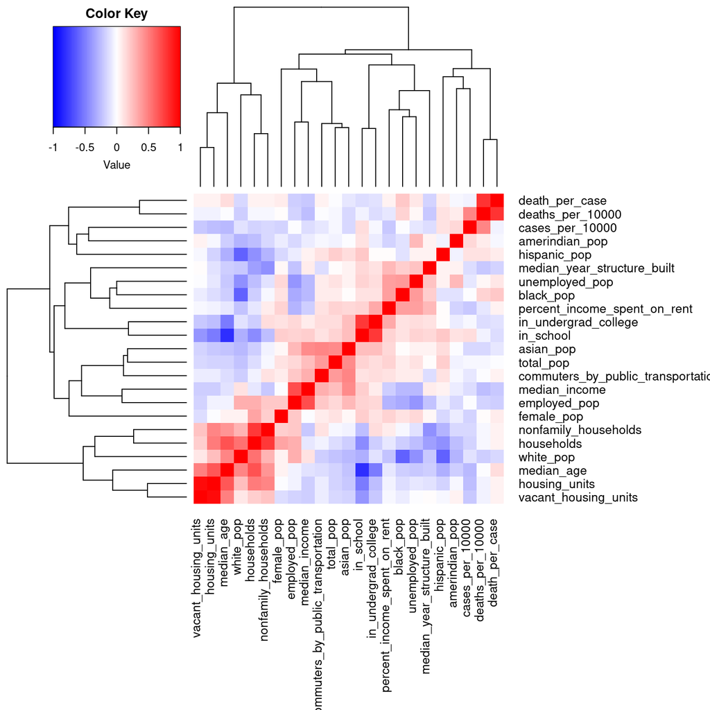

```r
hmap(cm, margins = c(14,14))
```

# Idea: Focus on states with Covid-19 outbreaks

Use a few states with many cases (training data) to learn a model of how demographics and socioeconomic factors affect fatalities and then apply the model to the other states (test data). I define the class variable by discretizing deaths per a population of 10,000 into below and above 10 deaths.

## Create class variable

“Bad” means a high fatality rate.

```r
cases_sel <- cases_sel %>% mutate(bad = as.factor(deaths_per_10000 > 10))
```

Check if the class variable is very imbalanced.

```r
cases_sel %>% pull(bad) %>% table()
```

```
## .
## FALSE  TRUE
##  1275  1864
```

```r
cases_sel %>% group_by(state) %>%
  summarize(bad_pct = sum(bad == TRUE)/n()) %>%
  arrange(desc(bad_pct))
```

```
## # A tibble: 51 x 2
##    state bad_pct
##    <fct>   <dbl>
##  1 DC      1
##  2 NJ      1
##  3 MS      0.988
##  4 AZ      0.933
##  5 LA      0.922
##  6 PA      0.881
##  7 SD      0.879
##  8 IN      0.870
##  9 MA      0.857
## 10 AR      0.853
## # … with 41 more rows
```

## Split into training and test data

I use TX, CA, FL, and NY to train.

```r
cases_train <- cases_sel %>% filter(state %in% c("TX", "CA", "FL", "NY"))
cases_train %>% pull(bad) %>% table()
```

```
## .
## FALSE  TRUE
##   148   293
```

```r
cases_test <-  cases_sel %>% filter(!(state %in% c("TX", "CA", "FL", "NY")))
cases_test %>% pull(bad) %>% table()
```

```
## .
## FALSE  TRUE
##  1127  1571
```

## Select Features

See: https://eriqande.github.io/rep-res-web/lectures/making-maps-with-R.html

```r
counties <- as_tibble(map_data("county"))
counties <- counties %>%
  rename(c(county = subregion, state = region)) %>%
  mutate(state = state.abb[match(state, tolower(state.name))]) %>%
  select(state, county, long, lat, group)
counties
```

```
## # A tibble: 87,949 x 5
##    state county   long   lat group
##    <chr> <chr>   <dbl> <dbl> <dbl>
##  1 AL    autauga -86.5  32.3     1
##  2 AL    autauga -86.5  32.4     1
##  3 AL    autauga -86.5  32.4     1
##  4 AL    autauga -86.6  32.4     1
##  5 AL    autauga -86.6  32.4     1
##  6 AL    autauga -86.6  32.4     1
##  7 AL    autauga -86.6  32.4     1
##  8 AL    autauga -86.6  32.4     1
##  9 AL    autauga -86.6  32.4     1
## 10 AL    autauga -86.6  32.4     1
## # … with 87,939 more rows
```

add variables to map data

```r
counties_all <- counties %>% left_join(cases_train %>%
    mutate(county = county_name %>% str_to_lower() %>%
        str_replace('\\s+county\\s*$', '')))
```

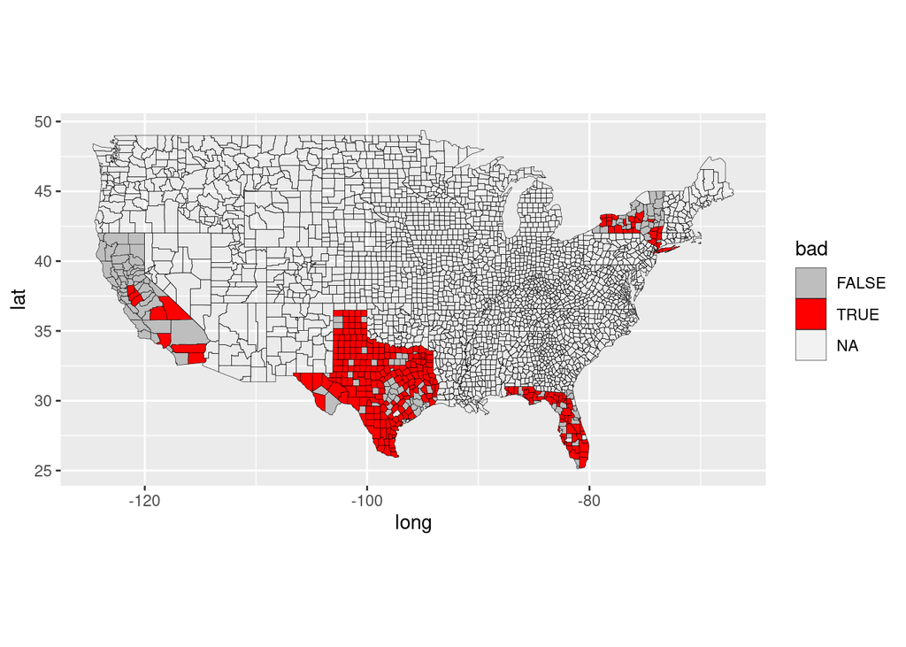

```r
ggplot(counties_all, aes(long, lat)) +
  geom_polygon(aes(group = group, fill = bad), color = "black", size = 0.1) +
    coord_quickmap() + scale_fill_manual(values = c('TRUE' = 'red', 'FALSE' = 'grey'))
```

Check variable importance

```r
library(FSelector)
cases_train %>%  chi.squared(bad ~ ., data = .) %>%
  arrange(desc(attr_importance)) %>% head()
```

```
##                  attr_importance
## deaths_per_10000       1.0000000
## county_name            0.9589002
## death_per_case         0.7537812
## state                  0.4859758
## cases_per_10000        0.4748534
## asian_pop              0.3513363
```

We have to remove the variable that was used to create the class variable.

```r
cases_train <- cases_train %>% select(-c(deaths_per_10000))
cases_train %>%  chi.squared(bad ~ ., data = .) %>%
  arrange(desc(attr_importance)) %>% head()
```

```
##                      attr_importance
## county_name                0.9589002
## death_per_case             0.7537812
## state                      0.4859758
## cases_per_10000            0.4748534
## asian_pop                  0.3513363
## in_undergrad_college       0.3301882
```

Remove more COVID19-related variables.

```r
cases_train <- cases_train %>% select(-death_per_case, -cases_per_10000)

cases_train %>%  chi.squared(bad ~ ., data = .) %>%
  arrange(desc(attr_importance)) %>% head(n = 10)
```

```
##                                    attr_importance
## county_name                              0.9589002
## state                                    0.4859758
## asian_pop                                0.3513363
## in_undergrad_college                     0.3301882
## median_income                            0.3155589
## commuters_by_public_transportation       0.3135452
## white_pop                                0.3035796
## total_pop                                0.2758432
## amerindian_pop                           0.2695219
## vacant_housing_units                     0.2563594
```

## Build a model

```r
library(caret)
```

Don’t use county or state name. The variables are not useful to compare between states and variables with many levels will make tree-based algorithms very slow.

```r
fit <- cases_train %>%
  train(bad ~ . - county_name - state,
    data = . ,
    #method = "rpart",
    method = "rf",
    #method = "nb",
    trControl = trainControl(method = "cv", number = 10)
    )
fit
```

[output not shown]

```r
#library(rpart.plot)
#rpart.plot(fit$finalModel, extra = 2)

varImp(fit)
```

```
## rf variable importance
##
##                                    Overall
## asian_pop                          100.000
## median_income                       86.481
## white_pop                           67.173
## commuters_by_public_transportation  58.315
## in_undergrad_college                58.243
## amerindian_pop                      50.738
## black_pop                           48.049
## hispanic_pop                        35.586
## employed_pop                        35.118
## unemployed_pop                      32.822
## vacant_housing_units                26.606
## total_pop                           23.977
## percent_income_spent_on_rent        16.921
## in_school                           10.951
## nonfamily_households                10.524
## households                           9.846
## median_year_structure_built          9.063
## housing_units                        1.193
## female_pop                           1.141
## median_age                           0.000
```

**Note:** You should probably take cases per day data instead of the total cases.

# Use the model from hard hit states for the rest of the US (test data)

caret does not make prediction with missing data

```r
cases_test <- cases_test %>% na.omit
```

```r
cases_test$bad_predicted <- predict(fit, cases_test)
```

Visualize the results

```r
counties_test <- counties %>% left_join(cases_test %>%
    mutate(county = county_name %>% str_to_lower() %>%
        str_replace('\\s+county\\s*$', '')))
```

Ground truth

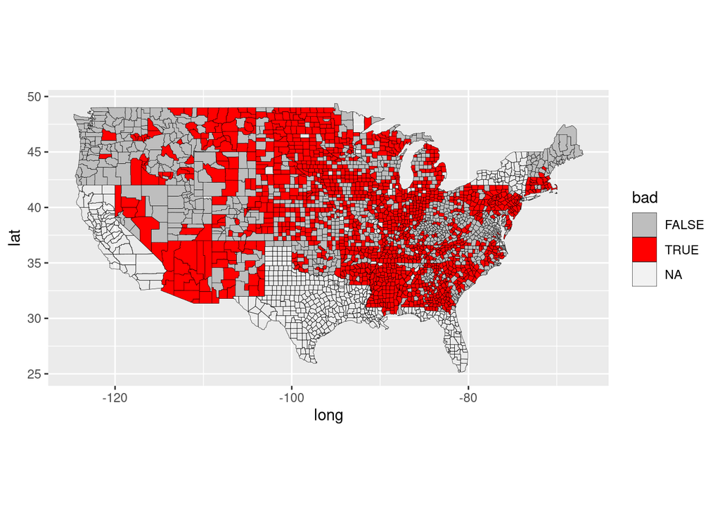

```r
ggplot(counties_test, aes(long, lat)) +
  geom_polygon(aes(group = group, fill = bad), color = "black", size = 0.1) +
  coord_quickmap() +
  scale_fill_manual(values = c('TRUE' = 'red', 'FALSE' = 'grey'))
```

Predictions

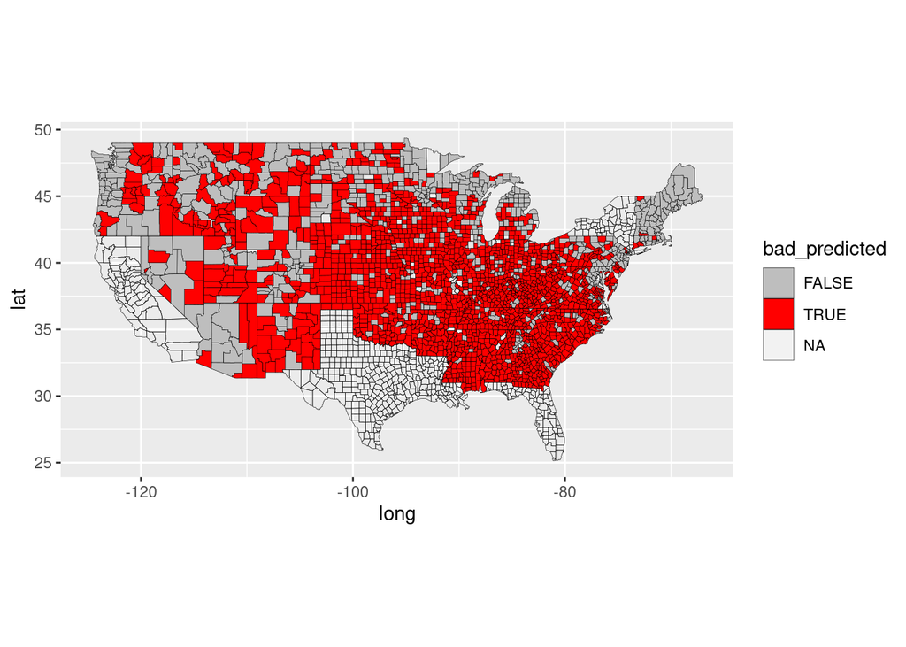

```r
ggplot(counties_test, aes(long, lat)) +
  geom_polygon(aes(group = group, fill = bad_predicted), color = "black", size = 0.1) +
    coord_quickmap() +
  scale_fill_manual(values = c('TRUE' = 'red', 'FALSE' = 'grey'))
```

Confusion matrix

```r
confusionMatrix(data = cases_test$bad_predicted, ref = cases_test$bad)
```

```
## Confusion Matrix and Statistics
##
##           Reference
## Prediction FALSE TRUE
##      FALSE   438  315
##      TRUE    687 1256
##
##                Accuracy : 0.6283
##                  95% CI : (0.6098, 0.6466)
##     No Information Rate : 0.5827
##     P-Value [Acc > NIR] : 7.483e-07
##
##                   Kappa : 0.1981
##
##  Mcnemar's Test P-Value : < 2.2e-16
##
##             Sensitivity : 0.3893
##             Specificity : 0.7995
##          Pos Pred Value : 0.5817
##          Neg Pred Value : 0.6464
##              Prevalence : 0.4173
##          Detection Rate : 0.1625
##    Detection Prevalence : 0.2793
##       Balanced Accuracy : 0.5944
##
##        'Positive' Class : FALSE
##
```